# Evaluation of AI Transparency in Decision-Based Circumstances in The Financial Sector

**Objective**

- Evaluation of AI transparency in decision-based circumstances in the financial sector.
- This project will compare the decision making process of custom trained AI models with ChatGPT 4.0 mini, Gemini 2.0 flash, Claude 3.5 Haiku models when it comes to financial decisions.

## Data processing

- Florida federal loan disbursement data for postsecondary institutions in the 2009-2010 Academic year.
- Data source: https://catalog.data.gov/dataset/national-student-loan-data-system-722b0/resource/6d111096-d565-48d7-b181-56aa87a38a97

**Attributes Used**

- School_Type: public, private, proprietary schools.
- Subsidized_Recipients: number of students that received the subsidized Federal Family Education Loan (FFEL).
- Unsubsidized_Recipients: number of students that recieved the unsubsidized FFEL loan.
- ParentPLUS_Recipient: number of students recieving Parent Loan for Undergradaute Students (PLUS).
- GradPLUS_Recipient: number of students recieving PLUS loans.

**Relevance of Dataset**

- Enables pattern finding when it comes to loan recipients across America.
- Does a different school type influence number of recipients?
- Provides an opportunity to study and understand model fairness and bias in model testing using finance data.

### Import Libraries

```python
from sklearn.metrics import accuracy_score, precision_score, recall_score, f1_score, roc_auc_score
from sklearn.discriminant_analysis import QuadraticDiscriminantAnalysis
from sklearn.model_selection import train_test_split,GridSearchCV
from sklearn.ensemble import VotingClassifier, StackingClassifier
from sklearn.linear_model import LogisticRegression
from sklearn.neural_network import MLPClassifier
from sklearn.preprocessing import StandardScaler
from sklearn.naive_bayes import GaussianNB
from itertools import combinations, chain
from imblearn.over_sampling import SMOTE
from sklearn.pipeline import Pipeline
from joblib import Parallel, delayed
from lightgbm import LGBMClassifier
from sklearn.svm import SVC
import pandas as pd
import numpy as np
import warnings


warnings.filterwarnings("ignore")
```

### Process Data

- Data was read from Excel.
- Missing column names were added.
- Relevant variables selected; school type was one hot encoded.
- Data input mistakes and inconsistencies are fixed.
- Missing data removed.

```python
def schoolEncode(school_type):
    return 1 if school_type=="PROPRIETARY" else 0


df = pd.read_excel("FL_Dashboard_AY2009_2010_Q3.xlsx", sheet_name="Award Year Summary", skiprows=4)
df = df.rename(columns={
    "Unnamed: 0": "OPE_ID",
    "Unnamed: 1": "School_Name",
    "Unnamed: 4": "School_Type",
    "FFEL SUBSIDIZED": "Subsidized_Recipients",
    "Unnamed: 6": "Subsidized_Loans",
    "FFEL UNSUBSIDIZED": "Unsubsidized_Recipients",
    "Unnamed: 11": "Unsubsidized_Loans",
    "FFEL PARENT PLUS": "ParentPLUS_Recipients",
    "Unnamed: 16": "ParentPLUS_Loans",
    "FFEL GRAD PLUS": "GradPLUS_Recipients",
    "Unnamed: 21": "GradPLUS_Loans"})

dfFiltered = df[["School_Name", "OPE_ID", "School_Type", "Subsidized_Recipients", "Unsubsidized_Recipients","ParentPLUS_Recipients", "GradPLUS_Recipients"]].copy()

dfFiltered["School_Type"] = dfFiltered["School_Type"].str.upper().str.strip()
dfFiltered = dfFiltered.dropna(subset=["School_Type"])

recipients = ["Subsidized_Recipients", "Unsubsidized_Recipients",
                  "ParentPLUS_Recipients", "GradPLUS_Recipients"]
dfFiltered[recipients] = dfFiltered[recipients].apply(pd.to_numeric, errors="coerce").fillna(0)

school = dfFiltered[["School_Name", "OPE_ID"]]

X = dfFiltered.drop(columns=["School_Name", "OPE_ID", "School_Type"])
y = dfFiltered["School_Type"].apply(schoolEncode)

X_train, X_test, y_train, y_test = train_test_split(X, y, test_size=0.2, random_state=42)

testIndicdes = X_test.index

schoolTest = school.loc[testIndicdes]
smote = SMOTE(random_state=42)
X_resampled, y_resampled = smote.fit_resample(X_train, y_train)
```

## Combinatorics to find best suited classification model

```python
models = {
    "nb": GaussianNB(),
    "svm": Pipeline([("scaler", StandardScaler()), ("model", SVC(probability=True))]),
    "mlp": Pipeline([("scaler", StandardScaler()), ("model", MLPClassifier(max_iter=500, random_state=42))]),
    "qda": Pipeline([("scaler", StandardScaler()), ("model", QuadraticDiscriminantAnalysis())]),
    "lgbm": LGBMClassifier(n_estimators=50, random_state=42)}

def evaluateCombinatorics(combination):
    tempResults = []

    selected_models = [(name, models[name]) for name in combination]

    try:
        voting = VotingClassifier(estimators=selected_models, voting="soft")
        voting.fit(X_resampled, y_resampled)
        y_prob_voting = voting.predict_proba(X_test)[:, 1]
        y_pred_voting = (y_prob_voting >= 0.3).astype(int)

        tempResults.append({
            "type": "Voting",
            "models": combination,
            "accuracy": accuracy_score(y_test, y_pred_voting),
            "precision": precision_score(y_test, y_pred_voting),
            "recall": recall_score(y_test, y_pred_voting),
            "f1": f1_score(y_test, y_pred_voting),
            "auc": roc_auc_score(y_test, y_prob_voting)})

    except Exception as e:
        print(f"Voting failed for {combination}: {e}")

    try:
        if len(selected_models) > 1:
            stacking = StackingClassifier(estimators=selected_models,final_estimator=LogisticRegression(max_iter=1000),passthrough=True,cv=3)
            stacking.fit(X_resampled, y_resampled)
            y_prob_stack = stacking.predict_proba(X_test)[:, 1]
            y_pred_stack = (y_prob_stack >= 0.3).astype(int)

            tempResults.append({
                "type": "Stacking",
                "models": combination,
                "accuracy": accuracy_score(y_test, y_pred_stack),
                "precision": precision_score(y_test, y_pred_stack),
                "recall": recall_score(y_test, y_pred_stack),
                "f1": f1_score(y_test, y_pred_stack),
                "auc": roc_auc_score(y_test, y_prob_stack)})

    except Exception as e:
        print(f"Stacking failed for {combination}: {e}")

    return tempResults

modelKeys = list(models.keys())
fullCombinations = []
for i in range(1, len(modelKeys) + 1):
    fullCombinations.extend(list(combinations(modelKeys, i)))

delayedTasks = [delayed(evaluateCombinatorics)(j) for j in fullCombinations]
resultsParallel = Parallel(n_jobs=-1, verbose=10)(delayedTasks)

fullResults = []
for result in resultsParallel:
    fullResults.extend(result)

resultsDf = pd.DataFrame(fullResults)

top = resultsDf.sort_values(by="f1", ascending=False).head(10)
print(top[["type", "models", "accuracy", "precision", "recall", "f1", "auc"]])
```

```
[Parallel(n_jobs=-1)]: Using backend LokyBackend with 24 concurrent workers.
[Parallel(n_jobs=-1)]: Done   1 tasks      | elapsed:    6.3s
[Parallel(n_jobs=-1)]: Done   4 out of  31 | elapsed:   16.0s remaining:  1.8min
[Parallel(n_jobs=-1)]: Done   8 out of  31 | elapsed:   36.8s remaining:  1.8min
[Parallel(n_jobs=-1)]: Done  12 out of  31 | elapsed:   42.2s remaining:  1.1min
[Parallel(n_jobs=-1)]: Done  16 out of  31 | elapsed:  1.1min remaining:  1.0min
[Parallel(n_jobs=-1)]: Done  20 out of  31 | elapsed:  1.3min remaining:   42.6s
[Parallel(n_jobs=-1)]: Done  24 out of  31 | elapsed:  1.3min remaining:   22.7s
[Parallel(n_jobs=-1)]: Done  28 out of  31 | elapsed:  1.5min remaining:    9.4s
```

```
        type                     models  accuracy  precision    recall  \
24  Stacking                (qda, lgbm)  0.646707   0.423983  0.883929
18  Stacking                (svm, lgbm)  0.646707   0.423656  0.879464
56  Stacking  (nb, svm, mlp, qda, lgbm)  0.646707   0.423326  0.875000
54  Stacking      (svm, mlp, qda, lgbm)  0.645509   0.422414  0.875000
50  Stacking       (nb, svm, qda, lgbm)  0.644311   0.421505  0.875000
36  Stacking            (nb, qda, lgbm)  0.645509   0.422078  0.870536
42  Stacking           (svm, qda, lgbm)  0.640719   0.419149  0.879464
30  Stacking            (nb, svm, lgbm)  0.646707   0.422319  0.861607
40  Stacking           (svm, mlp, lgbm)  0.640719   0.418803  0.875000
52  Stacking       (nb, mlp, qda, lgbm)  0.644311   0.420824  0.866071

          f1       auc
24  0.573082  0.758096
18  0.571843  0.752725
56  0.570597  0.759951
54  0.569767  0.760536
50  0.568940  0.757665
36  0.568513  0.757445
42  0.567723  0.758432
30  0.566814  0.753938
40  0.566474  0.756013
52  0.566423  0.758118
```

[output not shown]

- All model combinations essentially gave the same scores.
- The combinations with the slightest and insignificantly best score is the QDA and LGBM models.

- Grid search ensures best values for parameters.

```python
QDA_pipe = Pipeline([("scaler", StandardScaler()),("qda", QuadraticDiscriminantAnalysis())])

param_grid = {"estimators": []}

QDA_params = [0.0, 0.1, 0.3]
LGBM_estimators = [50, 100]
LGBM_depth = [3, 5]
LGBM_learning = [0.05, 0.1]

for i in QDA_params:
    for j in LGBM_estimators:
        for k in LGBM_depth:
            for l in LGBM_learning:
                QDA_model = QDA_pipe.set_params(qda__reg_param=i)
                LGBM_model = LGBMClassifier(n_estimators=j, max_depth=k, learning_rate=l, random_state=42, verbose=-1)
                estimatorCombination = [("qda", QDA_model), ("lgbm", LGBM_model)]
                param_grid["estimators"].append(estimatorCombination)

stack = StackingClassifier(estimators=[], final_estimator=LogisticRegression(max_iter=1000),passthrough=True,cv=3)
grid = GridSearchCV(estimator=stack,param_grid=param_grid,scoring="f1",cv=3,verbose=1)
grid.fit(X_resampled, y_resampled)

bestStack = grid.best_estimator_
y_prob = bestStack.predict_proba(X_test)[:, 1]
y_pred = (y_prob >= 0.3).astype(int)

print("Best Parameters:", grid.best_params_)

metrics = {
    "Accuracy": accuracy_score(y_test, y_pred),
    "Precision": precision_score(y_test, y_pred),
    "Recall": recall_score(y_test, y_pred),
    "F1 Score": f1_score(y_test, y_pred),
    "AUC-ROC": roc_auc_score(y_test, y_prob)}

for metric, value in metrics.items():
    print(f"{metric}: {value:.4f}")
```

```
Fitting 3 folds for each of 24 candidates, totalling 72 fits
Best Parameters: {'estimators': [('qda', Pipeline(steps=[('scaler', StandardScaler()),
                ('qda', QuadraticDiscriminantAnalysis(reg_param=0.3))])), ('lgbm', LGBMClassifier(learning_rate=0.05, max_depth=5, random_state=42, verbose=-1))]}
Accuracy: 0.6311
Precision: 0.4114
Recall: 0.8705
F1 Score: 0.5587
AUC-ROC: 0.7494
```

## Model Decision Making Evaluation

### SHAP

- Shapley Additive Explanations (SHAP) explains the output of machine learning solutions.
  - Showcases feature relevance in relation to the model.
  - Explains prediction results.
    - Calculates the contribution each prediction has in relation to the whole of the features.
- Gives the developers understanding as to the logic of the models and how well it grasps the financial trends.
- Not sensible to prediction randomness.
- Not all models are supported.
- Often an industry requirement so as to ensure ethical model transparency.

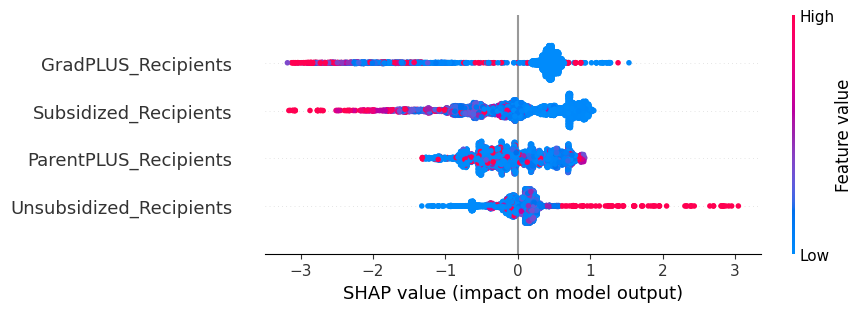

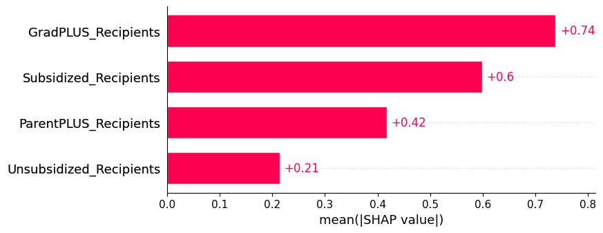

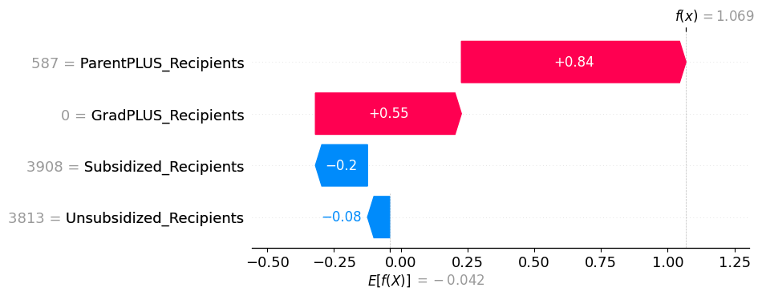

```python
import shap
import matplotlib.pyplot as plt

for name, model in bestStack.estimators:
    if name == "lgbm":
        LGBM_model = model
        break

LGBM_model.fit(X_resampled, y_resampled)

explainer = shap.Explainer(LGBM_model, X_resampled)
SHAP_values = explainer(X_resampled)

shap.plots.beeswarm(SHAP_values)
plt.show()

shap.plots.bar(SHAP_values)
plt.show()

index = 0
shap.plots.waterfall(SHAP_values[index])
```

## LIME

- Local Interpretable Model-Agnostic Explanations (LIME) takes a single prediction and assumes it is the representation of the entirety of predictions so as to evaluate model transparency.
- Easier to understand than SHAP.
- Works for any model.
- Sensible to prediction randomness.
- Secondary layer of transparency.

```python
import lime
import lime.lime_tabular
import numpy as np

i = 0

LIME_explainer = lime.lime_tabular.LimeTabularExplainer(training_data=np.array(X_resampled),feature_names=X_resampled.columns.tolist(),class_names=["Public/Private", "Proprietary"],mode="classification")
LIME_explain = LIME_explainer.explain_instance(data_row=X_test.iloc[i],predict_fn=bestStack.predict_proba)
LIME_explain.show_in_notebook()
```

[output not shown]

- The stacked solution predicts that, no matter the loan, there is 71% chance the school is either private or public.
  - Subsidized and Parent PLUST loans are more commonplace in public and private schools when compared to proprietary schools.
- It is only 29% likely for the school to be proprietary if it receives any form of loan.
  - Proprietary schools tend to receive more unsubsidized loans and some GradPLUS when compared to public or private schools.

### Decision Logging into file

- Transparency Data logging for future analysis.
- Provides stored accountability for trained models and prediction performance.

```python
import datetime
import shap
import json

def logDecision(input_row, prediction, probability, SHAP_values, log_file="decision_log.jsonl"):
    entry = {
        "timestamp": datetime.datetime.now().isoformat(),
        "input": input_row.to_dict(),
        "prediction": int(prediction),
        "probability": float(probability),
        "SHAP_values": dict(zip(input_row.index, SHAP_values.values)),}

    with open(log_file, "a") as f:
        f.write(json.dumps(entry) + "\n")

inputRow = X_test.iloc[0]
prediciton = bestStack.predict_proba([inputRow])[0][1]
probability = int(prediciton >= 0.3)
SHAP_val = shap.Explainer(bestStack.named_estimators_["lgbm"], X_resampled)(inputRow.to_frame().T)[0]

logDecision(inputRow, probability, prediciton, SHAP_val)
```

## Fairness Evaluation

### Loan Approval Rates and Disparate Impact Rate

- Computes the rate at which the models predicts an approval for loan recipients at the different schools.
- Ensures that a model has not learned to become biased towards one type of school and seem to incline for other types of universities to receive loans more than it mathematically should.

```python
y_prob = bestStack.predict_proba(X_test)[:, 1]
y_pred = (y_prob >= 0.3).astype(int)

resultsDf = X_test.copy()
resultsDf["true"] = y_test.values
resultsDf["pred"] = y_pred
resultsDf["prob"] = y_prob

publicMask = (y_test == 0)
profitMask = (y_test == 1)

approvalRate_public = resultsDf.loc[publicMask, "pred"].mean()
approvalRate_profit = resultsDf.loc[profitMask, "pred"].mean()

disparate_impact_ratio = approvalRate_profit/approvalRate_public
print(f"Disparate Impact Ratio: {disparate_impact_ratio}")
```

```
Disparate Impact Ratio: 1.9064420122887864
```

- Model seems to predict 91% more often that loans will be given to for-profit schools when compared to not for profit schools.
- There is an evident group disparity which was a trend present in the data; there must always be a type of school that receives more loans than others.

## GPT Model Evaluation

```python
# Sample case to interrogate model

print(X_test.iloc[0])
```

```
Subsidized_Recipients      1305.0
Unsubsidized_Recipients    1323.0
ParentPLUS_Recipients       263.0
GradPLUS_Recipients           0.0
Name: 501, dtype: float64
```

### Gemini 2.0 Flash

- Many repeated prompts were asked to ensure consistency.
- Prompt variation 1:
  - a school has the following loan distribution:
    - Subsidized Recipients: 1305
    - Unsubsidized Recipients: 1323
    - ParentPLUS Recipients: 263
    - GradPLUS Recipients: 0
    - An ML model predicted the school as a for-profit with 71% chance. Explain why this makes sense.
- Prompt variation 2:
  - Based on the loan data below, which features do you think most strongly influenced the model’s decision. Explain why.
    - Subsidized: 1305
    - Unsubsidized: 1323
    - ParentPLUS: 263
    - GradPLUS: 0
- Prompt variation 3:
  - Given this school's loan profile: Subsidized=1305, Unsubsidized=1323, ParentPLUS=263, GradPLUS=0
  - Explain why a model would label this school as for-profit.
- Answer:
  - The models prediction of the school being for-profit was based due to it having no GradPLUS loans received was the greatest indicator. GradPLUS loans are for graduate programs and if its missing indicates a lack of graduate programs. This is catalogued as a trait more common in for-profit schools.
  - Also, the ParentPLUS loans are taken out by parents of undergraduate students are a more traditional type of loan most common in four-year schools. A low amount of these loans points out a less traditional student body.
  - It acknowledged that both subsidized and unsubsidized loans in combination with the deductions above, strengthened the case for the school being for profit.
- Consistency Prompts:
  - Prompt 1:
    - A public school has this loan profile:
    - Subsidized: 1305
    - Unsubsidized: 1323
    - ParentPLUS: 263
    - GradPLUS: 0
    - Does this profile align with a loan profile of a public school?
  - Prompt 2:
    - A for-profit school has the same loan profile. How does it that change your evaluation?
- Consistency in answers was somewhat sustained always using the same keywords of "complete absence" and "big clue".
  - Initially Gemini was asked to affirm an answer. Then it was asked to come up with its own answer. In the first prompt, it sided with the idea of the school being public. However, it seems it has limited capacity to think outside of what is mentioned as it changed its reasoning once mentioned another possibility which aligns better with what it said in previous prompts. Reasoning was unbiased and more as in limited.
- Used real-world facts to back up positions, giving an explanation without hallucinations.
- Responses were logged in text files.

### ChatGPT 4.0 Mini

- Many repeated prompts were asked to ensure consistency.
- Prompt variation 1:
  - a school has the following loan distribution:
    - Subsidized Recipients: 1305
    - Unsubsidized Recipients: 1323
    - ParentPLUS Recipients: 263
    - GradPLUS Recipients: 0
    - An ML model predicted the school as a for-profit with 71% chance. Explain why this makes sense.
- Prompt variation 2:
  - Based on the loan data below, which features do you think most strongly influenced the model’s decision. Explain why.
    - Subsidized: 1305
    - Unsubsidized: 1323
    - ParentPLUS: 263
    - GradPLUS: 0
- Prompt variation 3:
  - Given this school's loan profile: Subsidized=1305, Unsubsidized=1323, ParentPLUS=263, GradPLUS=0
  - Explain why a model would label this school as for-profit.
- Answer:
  - The models prediction of the school being for-profit was based due to it having no GradPLUS loans received was the greatest indicator. GradPLUS loans are for graduate programs and if its missing indicates a lack of graduate programs. This is catalogued as a trait more common in for-profit schools.
  - Also, the ParentPLUS loans are taken out by parents of undergraduate students are a more traditional type of loan most common in four-year schools. A low amount of these loans points out a less traditional student body.
  - It acknowledged that both subsidized and unsubsidized loans in combination with the deductions above, strengthened the case for the school being for profit.
- Consistency Prompts:
  - Prompt 1:
    - A public school has this loan profile:
    - Subsidized: 1305
    - Unsubsidized: 1323
    - ParentPLUS: 263
    - GradPLUS: 0
    - Does this profile align with a loan profile of a public school?
  - Prompt 2:
    - A for-profit school has the same loan profile. How does it that change your evaluation?
- Consistency in answers was somewhat sustained always using the same keywords of "complete absence" and "big clue".
  - Initially ChatGPT 4.0 Mini was asked to affirm an answer. Then it was asked to come up with its own answer. In the first prompt, it sided with the idea of the school being for-profit rather than public. In the second prompt, it estimated the school to be for-profit. It seems the ChatGPT 4.0 Mini has a far better reasoning capacity than that of Gemini Flash 2.0.
- Used real-world facts to back up positions, giving an explanation without hallucinations.
- Responses were logged in text files.

### Claude 3.5 Haiku

- Many repeated prompts were asked to ensure consistency.
- Prompt variation 1:
  - a school has the following loan distribution:
    - Subsidized Recipients: 1305
    - Unsubsidized Recipients: 1323
    - ParentPLUS Recipients: 263
    - GradPLUS Recipients: 0
    - An ML model predicted the school as a for-profit with 71% chance. Explain why this makes sense.
- Prompt variation 2:
  - Based on the loan data below, which features do you think most strongly influenced the model’s decision. Explain why.
    - Subsidized: 1305
    - Unsubsidized: 1323
    - ParentPLUS: 263
    - GradPLUS: 0
- Prompt variation 3:
  - Given this school's loan profile: Subsidized=1305, Unsubsidized=1323, ParentPLUS=263, GradPLUS=0
  - Explain why a model would label this school as for-profit.
- Answer:
  - The models prediction of the school being for-profit was based due to it having no GradPLUS loans received was the greatest indicator. GradPLUS loans are for graduate programs and if its missing indicates a lack of graduate programs. This is catalogued as a trait more common in for-profit schools.
  - Also, the ParentPLUS loans are taken out by parents of undergraduate students are a more traditional type of loan most common in four-year schools. A low amount of these loans points out a less traditional student body.
  - It acknowledged that both subsidized and unsubsidized loans in combination with the deductions above, strengthened the case for the school being for profit.
- Consistency Prompts:
  - Prompt 1:
    - A public school has this loan profile:
    - Subsidized: 1305
    - Unsubsidized: 1323
    - ParentPLUS: 263
    - GradPLUS: 0
    - Does this profile align with a loan profile of a public school?
  - Prompt 2:
    - A for-profit school has the same loan profile. How does it that change your evaluation?
- Consistency in answers was somewhat sustained always using the same keywords of "complete absence" and "big clue".
  - Initially Claude 3.5 Haiku was asked to affirm an answer. Then it was asked to come up with its own answer. In the first prompt, it sided with the idea of the school being public rather than public, citing higher Parent PLUS loans and low number of Parent PLUS loans, as well as a large number of direct loans. In the second prompt, it estimated the school to be for-profit citing no Grad PLUS loans indicating small number of Graduate programs and possibly more financially independent student population. It seems to be the middle ground of Gemini Flash 2.0 and ChatGPT 4.0 Mini.
- Used real-world facts to back up positions, giving an explanation without hallucinations.
- Responses were logged in text files.

## Conclusion

**Objective**

- Evaluation of AI transparency in decision-based circumstances in the financial sector.
- This project will compare the decision making process of custom trained AI models with ChatGPT 4.0 mini, Gemini 2.0 flash, Claude 3.5 Haiku models when it comes to financial decisions.

**Dataset**

- Florida Federal Loan Disbursement dataset from 2009-2010 academic year.
- Contains public, private, proprietary school types.
- Contains Subsidized, unsubsidized, ParentPLUS, GradPLUS.
- Relevant variable such as loan and school type were selected; categorical values that require a classifier solution.

**GPT Models**

**How does GPT models compare to stacked model solution when dealing with transparency?**

- It is easier to communicate and question with a GPT that is trained to synthesize answers from human speech rather than a collection of ML libraries. A significant amount of programming was done to delve deep into a model's reasoning, otherwise this information would be complicated to get out of a GPT.
- While the stack ML solution required SHAP and LIME to understand internal workings, GPT models were straightforward in logic when asked for this information.
- The ML stack used SHAP and LIME to get exact numerical values for contribution of features, when GPT models simply stated, only with logical proof, what features would likely be most influential.
- It is possible that GPT Models may be hiding internals by simply abiding to logic rather than numeric proof.
  - ML stacked model is quite open to read its features and how it works to a very great extent.
- Ml model stack uses SHAP and LIME to evaluate a model's consistency in predictions, while the consistency of GPT models may erode away if given the proper wording in the prompt.
- GPT models are not deterministic.
  - ML model stack is significantly more reproducible than a GPT that may vary from time to time; one day it might even shut down.
  - Difficult to audit a GPT that changes all the time, while the stacked model has the ability to set its internal computations to a reproducible state.

## References

- https://www.w3schools.com/python/python_ml_auc_roc.asp
- https://www.geeksforgeeks.org/linear-and-quadratic-discriminant-analysis-using-sklearn/
- https://www.science.smith.edu/~jcrouser/SDS293/labs/lab5-py.html
- https://scikit-learn.org/0.16/modules/generated/sklearn.qda.QDA.html
- https://machinelearningmastery.com/stacking-ensemble-machine-learning-with-python/
- https://medium.com/@brijesh_soni/stacking-to-improve-model-performance-a-comprehensive-guide-on-ensemble-learning-in-python-9ed53c93ce28
- https://www.geeksforgeeks.org/stacking-in-machine-learning-2/
- https://scikit-learn.org/stable/modules/generated/sklearn.ensemble.StackingClassifier.html
- https://scikit-learn.org/stable/modules/generated/sklearn.ensemble.VotingClassifier.html
- https://www.geeksforgeeks.org/ml-voting-classifier-using-sklearn/
- https://www.blog.trainindata.com/smote-in-python-a-guide-to-balanced-datasets/
- https://medium.com/@tam.tamanna18/handling-imbalanced-datasets-in-python-methods-and-procedures-7376f99794de
- https://www.geeksforgeeks.org/smote-for-imbalanced-classification-with-python/
- https://scikit-learn.org/stable/modules/compose.html
- https://scikit-learn.org/stable/auto_examples/classification/plot_classifier_comparison.html
- https://lightgbm.readthedocs.io/en/stable/pythonapi/lightgbm.LGBMClassifier.html
- https://www.geeksforgeeks.org/parallel-processing-in-python/
- https://www.zendesk.com/blog/ai-transparency/
- https://crfm.stanford.edu/fmti/May-2024/index.html
- https://academy.pega.com/topic/model-transparency/v1
- https://shap.readthedocs.io/en/latest/
- https://lime-ml.readthedocs.io/en/latest/
- https://medium.com/data-science/ai-fairness-explanation-of-disparate-impact-remover-ce0da59451f1
- https://www.deepchecks.com/glossary/model-fairness/#:~:text=Model%20fairness%20refers%20to%20the,as%20gender%2C%20race%20or%20age.
- https://haas.berkeley.edu/wp-content/uploads/What-is-fairness_-EGAL2.pdf
- https://arize.com/blog/evaluating-model-fairness/
- https://aif360.readthedocs.io/en/latest/modules/generated/aif360.sklearn.metrics.disparate_impact_ratio.html
- https://dataplatform.cloud.ibm.com/docs/content/wsj/model/wxgov-disparate-impact-metric.html?context=wx&%3Baudience=wdp
- https://www.evidentlyai.com/classification-metrics/classification-threshold
- https://medium.com/data-science/achieve-better-classification-results-with-classificationthresholdtuner-39c5d454637e
- https://www.geeksforgeeks.org/decision-threshold-in-machine-learning/